# Testing Lanchester’s laws in coral reef fish

David Cerny

1/28/2018

# Data preparation

Read in the data spreadsheets:

```r
sheet <- read.csv("/Users/David/Documents/College/2017–18/Winter 2018/FBQ_git/LiveFishInteraction_Feb9.csv", sep = ",", strip.white = TRUE)
scored <- read.csv("/Users/David/Documents/College/2017–18/Winter 2018/FBQ_git/ScoredFishInteraction_Feb19.csv", sep = ",", strip.white = TRUE)

# Combining the two is easier when dealing with the relevant columns alone. These are:
# Species.A, Species.B, Group.A, Group.B, and Winner.
ABwin_live <- sheet[,c(4,6,8,9,10)]
ABwin_scored <- scored[,c(10,12,13,15,16)]
both <- rbind(ABwin_live, ABwin_scored)

# Create new versions of the three data frames that include one-on-one interactions only:
sheet_oneonone <- sheet[sheet$Group.A == 1 & sheet$Group.B == 1,]
scored_oneonone <- scored[scored$Group.A == 1 & scored$Group.B == 1,]
both_oneonone <- both[both$Group.A == 1 & both$Group.B == 1,]
```

### Clean-up

Step 1. Unidentified species are marked with an asterisk. Exclude them from the matrix based on this criterion:

```r
drop_ufos <- function(df) {
  # Dummy vector for storing the numbers of the rows with unidentifiable species:
  tobedropped <- vector()
  for (i in 1:nrow(df)) {
    if (grepl("*", df$Species.A[i], fixed = TRUE) == TRUE |
        grepl("*", df$Species.B[i], fixed = TRUE) == TRUE |
        grepl("*", df$Winner[i], fixed = TRUE) == TRUE) {
      tobedropped <- c(tobedropped, i)
    }
  }
  return(df[-c(tobedropped),])
}

sheet2 <- drop_ufos(sheet)
scored2 <- drop_ufos(scored)
both2 <- drop_ufos(both)
sheet_ooo2 <- drop_ufos(sheet_oneonone)
scored_ooo2 <- drop_ufos(scored_oneonone)
both_ooo2 <- drop_ufos(both_oneonone)
```

Step 2. Remove intraspecific interactions (a few of these were scored for live observations in the beginning, before it was decided to selectively focus on interspecific interactions only):

```r
drop_intra <- function(df) {
  tobedropped <- vector()
  for (i in 1:nrow(df)) {
    if (identical(as.character(df$Species.A[i]), as.character(df$Species.B[i])) == TRUE) {       tobedropped <- c(tobedropped, i)
    }
  }
  if (length(tobedropped) > 0) {
    return(df[-c(tobedropped),])
  } else {
    return(df)
  }
}

sheet3 <- drop_intra(sheet2)
scored3 <- drop_intra(scored2)
both3 <- drop_intra(both2)
sheet_ooo3 <- drop_intra(sheet_ooo2)
scored_ooo3 <- drop_intra(scored_ooo2)
both_ooo3 <- drop_intra(both_ooo2)
```

Step 3. Drop “Striated Surgeonfish” from the matrices, as this is likely a composite category comprising both striated and brown surgeonfish. These species may have different dominance ranks, but are almost indistinguishable in appearance.

```r
no_surgeon <- function(df) {
  return(df[df$Species.A != "Striated Surgeonfish" & df$Species.B != "Striated Surgeonfish",])
}

sheet4 <- no_surgeon(sheet3)
scored4 <- no_surgeon(scored3)
both4 <- no_surgeon(both3)
sheet_ooo4 <- no_surgeon(sheet_ooo3)
scored_ooo4 <- no_surgeon(scored_ooo3)
both_ooo4 <- no_surgeon(both_ooo3)
```

### Generating a dominance matrix

Extract the levels of `Species.A` and `Species.B` and use them as the rows and columns of the dominance matrix:

```r
# The union of the species listed in the "Species A" and "Species B" columns will be used
# as the rows and columns of a new matrix filled with zeros:
emptymatrix <- function(df) {
  species <- union(levels(factor(df$Species.A)), levels(factor(df$Species.B)))
  rownum <- length(species)
  newmatrix <- matrix(0, nrow = rownum, ncol = rownum)
  row.names(newmatrix) <- species
  colnames(newmatrix) <- species
  return(newmatrix)
}

dommatrix <- emptymatrix(sheet4)
scoredmatrix <- emptymatrix(scored4)
bothmatrix <- emptymatrix(both4)
domooo <- emptymatrix(sheet_ooo4)
scoredooo <- emptymatrix(scored_ooo4)
bothooo <- emptymatrix(both_ooo4)

# If species A won over species B (winner = A), add 1 to the cell in column A and row B.
# If species B won over species A (winner = B), add 1 to the cell in column B and row A.
# An increment function will be used to increase the value of each cell accordingly:
inc <- function(x) # credit: Grega Kešpret, Stack Overflow
{
 eval.parent(substitute(x <- x + 1))
}

# Now apply it to populate the matrix:
populate <- function(sheet, df) {
  for (i in 1:nrow(sheet)) {
    spec_a <- as.character(sheet$Species.A[i])
    spec_b <- as.character(sheet$Species.B[i])
    winner <- as.character(sheet$Winner[i])
    if (identical(spec_a, winner) == TRUE) {
      inc(df[as.character(spec_b), as.character(spec_a)])
    }
    if (identical(spec_b, winner) == TRUE) { # This should be equivalent to "else"
      inc(df[as.character(spec_a), as.character(spec_b)])
    }
  }
  diag(df) <- NA
  return(df)
}

dommatrix <- populate(sheet4, dommatrix)
scoredmatrix <- populate(scored4, scoredmatrix)
bothmatrix <- populate(both4, bothmatrix)
domooo <- populate(sheet_ooo4, domooo)
scoredooo <- populate(scored_ooo4, scoredooo)
bothooo <- populate(both_ooo4, bothooo)
```

Convert from matrices to data frames for easier manipulation:

```r
convert_to_df <- function(df) {
  frame <- as.data.frame(df, stringsAsFactors = FALSE)
  for (i in 1:ncol(df)) {
  frame[,i] <- as.numeric(frame[,i])
  }
  return(frame)
}

domall <- convert_to_df(dommatrix)
scoredall <- convert_to_df(scoredmatrix)
bothall <- convert_to_df(bothmatrix)
liveoooall <- convert_to_df(domooo)
scoredoooall <- convert_to_df(scoredooo)
bothoooall <- convert_to_df(bothooo)
```

Exclude cornetfish, the only predator in the dataset. (Note: the fact that this is done here, at the matrix formatting stage rather than at the data clean-up stage, simply reflects the point at which the decision was taken during the actual analysis. Excluding a taxon from the matrix using the method below is equivalent to excluding it from the data sheet.)

```r
# Exclude a taxon from a matrix:
exclude <- function(df, taxon) {
  colrow <- c(which(row.names(df) == taxon), which(colnames(df) == taxon))
  excluded <- df[-colrow[1], -colrow[2]]
  return(excluded)
}

# Note: since there are no interactions involving cornetfish in the video-only data,
# we only need to exclude it from the live-only and combined datasets.
nocornet_domall <- exclude(domall, "Cornetfish")
nocornet_bothall <- exclude(bothall, "Cornetfish")
nocornet_live <- exclude(liveoooall, "Cornetfish")
nocornet_both <- exclude(bothoooall, "Cornetfish")
```

### Matrix completeness:

```r
compl <- function(df) {
  counter <- 0
  for (i in 1:nrow(df)) {
    for (j in 1:ncol(df)) {
      if (!is.na(df[i,j]) & df[i,j] == 0 & df[j,i] == 0) {
        counter <- counter + 1
      }
    }
  }
  return(100*(1 - (counter/(nrow(df)*(nrow(df) - 1)))))
}
paste("The completeness of the live-only all-species matrix is ", compl(nocornet_domall), "%", sep = ""); paste("The completeness of the video-only all-species matrix is ", compl(scoredall), "%", sep = ""); paste("The completeness of the combined all-species matrix is ", compl(nocornet_bothall), "%", sep = ""); paste("The completeness of the live-only one-on-one all-species matrix is ", compl(nocornet_live), "%", sep = ""); paste("The completeness of the video-only one-on-one all-species matrix is ", compl(scoredoooall), "%", sep = ""); paste("The completeness of the combined one-on-one all-species matrix is ", compl(nocornet_both), "%", sep = "")
```

```
## [1] "The completeness of the live-only all-species matrix is 38.961038961039%"
```

```
## [1] "The completeness of the video-only all-species matrix is 27.2058823529412%"
```

```
## [1] "The completeness of the combined all-species matrix is 37.9446640316206%"
```

```
## [1] "The completeness of the live-only one-on-one all-species matrix is 33.7662337662338%"
```

```
## [1] "The completeness of the video-only one-on-one all-species matrix is 25%"
```

```
## [1] "The completeness of the combined one-on-one all-species matrix is 33.596837944664%"
```

### Landau’s *h*-index:

```
## h-modified = 0.3205632
##  p-value= 0.0014
```

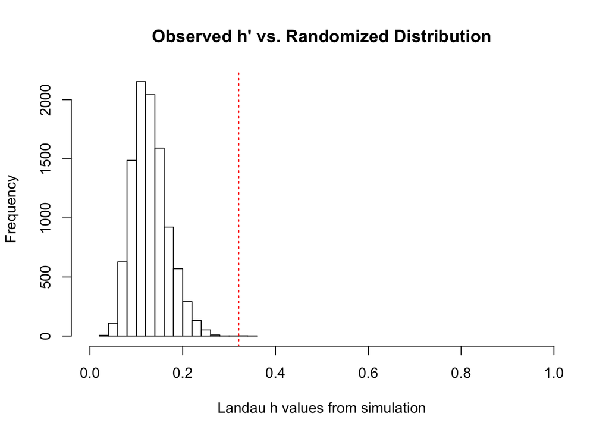

```r
library(gdata)
library(compete)

# To determine linearity, we need to make our dominance matrix symmetric. Below, we do
# this by subtracting the lower triangle from the upper triangle, and flipping the results
# around the diagonal:
symmatrix <- function(df) {
  # Going through the upper triangle column-wise corresponds to going through the lower
  # triangle row-wise:
  triangle <- as.numeric(upperTriangle(df)) - as.numeric(lowerTriangle(df), byrow = TRUE)
  # Replace the upper triangle in the default column-wise order:
  symmat <- matrix(NA, nrow = nrow(df), ncol = ncol(df))
  upperTriangle(symmat) <- triangle
  # Replace the lower triangle in the row-wise order:
  lowerTriangle(symmat, byrow = TRUE) <- triangle
  return(symmat)
}

# Note that the p-values are simulation-based, and therefore stochastic: they will differ
# slightly between runs
devries(nocornet_domall, Nperms = 10000, history = FALSE, plot = TRUE)
```

```
## h-modified = 0.2982794
##  p-value= 0.0499
```

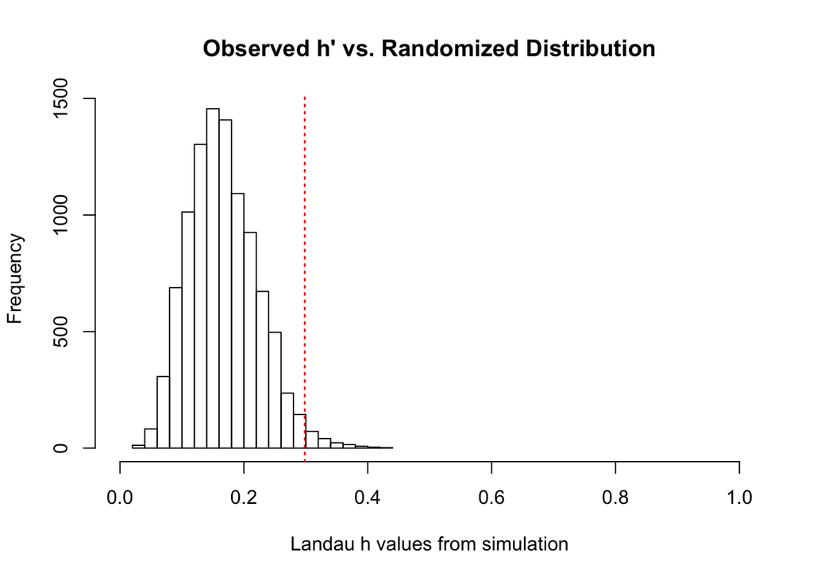

```r
devries(scoredall, Nperms = 10000, history = FALSE, plot = TRUE)
```

```
## h-modified = 0.2961997
##  p-value= 0.0022
```

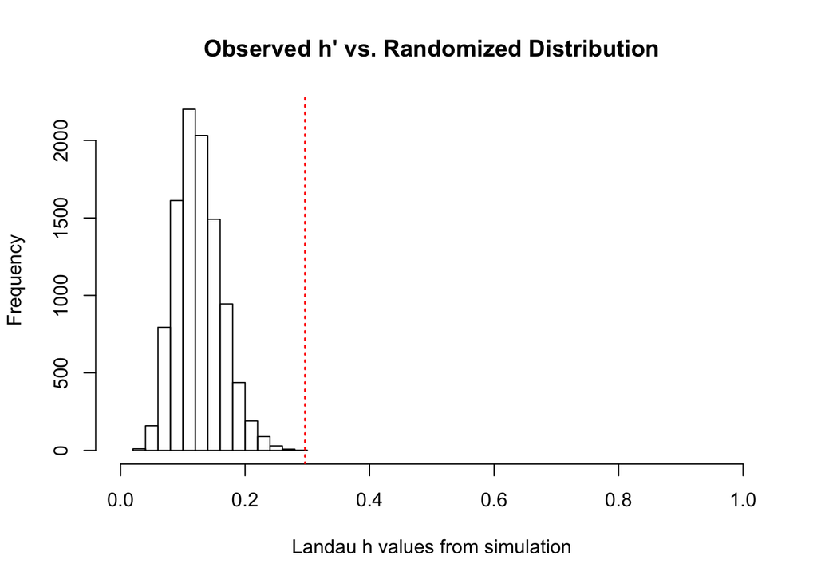

```r
devries(nocornet_bothall, Nperms = 10000, history = FALSE, plot = TRUE)
```

```
## h-modified = 0.2776736
##  p-value= 0.0103
```

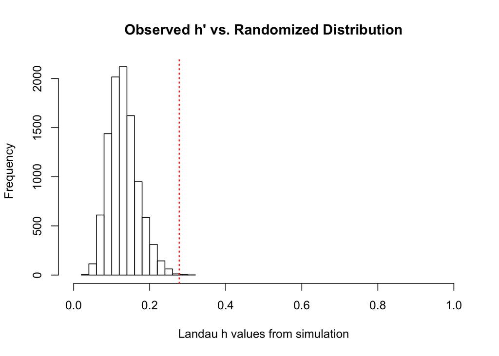

```r
devries(nocornet_live, Nperms = 10000, history = FALSE, plot = TRUE)
```

```
## h-modified = 0.2984554
##  p-value= 0.0533
```

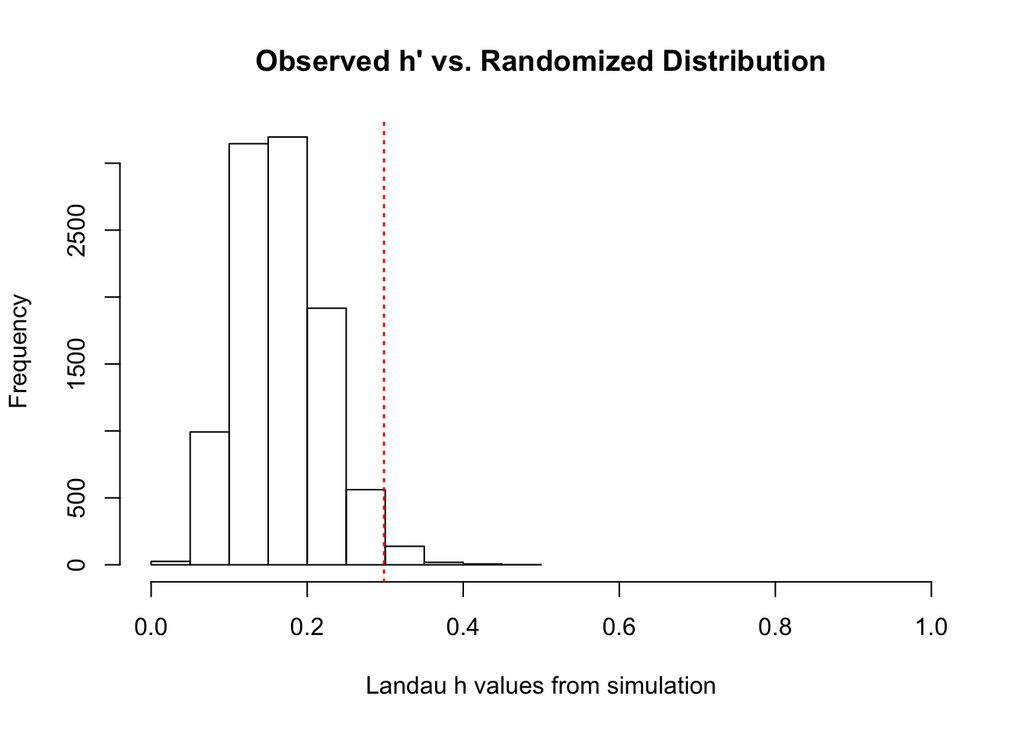

```r
devries(scoredoooall, Nperms = 10000, history = FALSE, plot = TRUE)
```

```
## h-modified = 0.2681971
##  p-value= 0.006
```

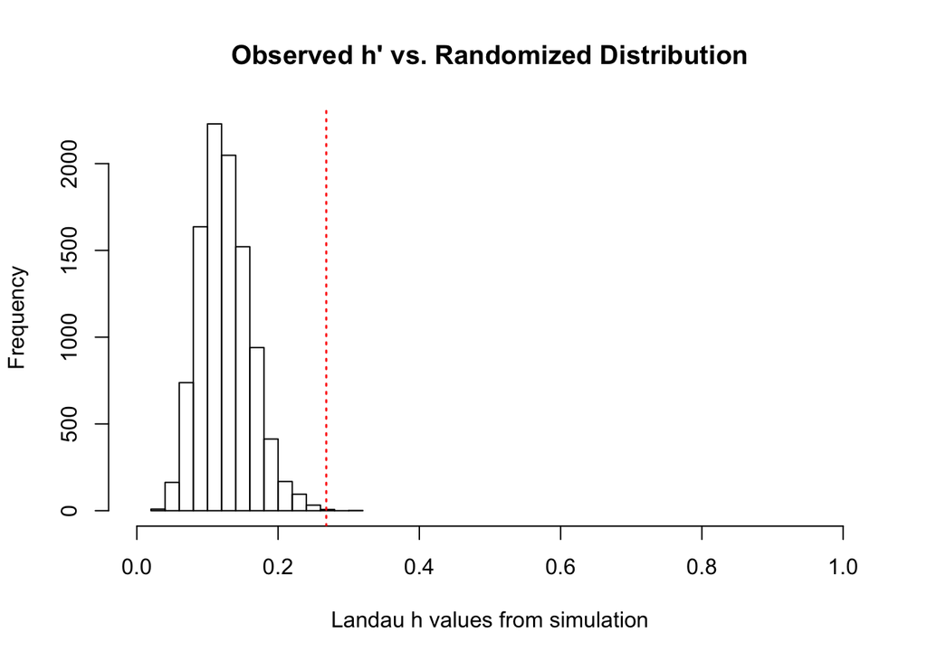

```r
devries(nocornet_both, Nperms = 10000, history = FALSE, plot = TRUE)
```

Uncomment the code below (and change the paths as needed) to print the matrices:

```r
# write.table(nocornet_domall, "/Users/David/Documents/College/2017–18/Winter 2018/FBQ_git/live_only_matrix.txt", quote = FALSE, sep = "\t")
# write.table(scoredall, "/Users/David/Documents/College/2017–18/Winter 2018/FBQ_git/video_only_matrix.txt", quote = FALSE, sep = "\t")
# write.table(nocornet_bothall, "/Users/David/Documents/College/2017–18/Winter 2018/FBQ_git/both_datasets_matrix.txt", quote = FALSE, sep = "\t")
# write.table(nocornet_live, "/Users/David/Documents/College/2017–18/Winter 2018/FBQ_git/live_only_one-on-one_matrix.txt", quote = FALSE, sep = "\t")
# write.table(scoredoooall, "/Users/David/Documents/College/2017–18/Winter 2018/FBQ_git/video_only_one-on-one_matrix.txt", quote = FALSE, sep = "\t")
# write.table(nocornet_both, "/Users/David/Documents/College/2017–18/Winter 2018/FBQ_git/both_datasets_one-on-one_matrix.txt", quote = FALSE, sep = "\t")
```

### CBI

The code below was used to compute the Clutton-Brock et al. dominance index (Clutton-Brock et al. 1979, 1982).

```r
# Remember:
# If A won over B, add 1 to [B,A]
# If A won over C, add 1 ro [C,A]
# -> So the A column represents the species that A dominates (A wins)
# If A lost to B, add 1 to [A,B]
# If A lost to C, add 1 to [A,C]
# -> So the A row represents the species that dominate A (A losses)
# (B + b + 1)/(L + l + 1)
cbi <- function(df, species) {
  # number of entries in column B that are neither 0 nor NA:
  B <- sum(df[,species] != 0, na.rm = TRUE)
  # species corresponding to those entries:
  dominates <- rownames(df)[which(df[,species] != 0)]
  # number of entries in the columns corresponding to those species that are neither 0 nor NA:
  if (length(dominates) > 0) {
    b <- sum(subset(df, select = dominates) != 0, na.rm = TRUE)
  } else {
    b <- 0
  }
  # number of entries in row B that are neither 0 nor NA:
  L <- sum(df[species,], na.rm = TRUE)
  # species corresponding to those entries:
  dominated <- colnames(df)[which(df[species,] != 0)]
  # number of entries in the rows corresponding to those species that are neither 0 nor NA:
  if (length(dominated) > 0) {
    l <- sum(subset(df, rownames(df) %in% dominated) != 0, na.rm = TRUE)
  } else {
    l <- 0
  }
  return((B + b + 1)/(L + l + 1))
}

# Apply it to the full matrix:
cbi_hierarchy <- function(df) {
  cbi_matrix <- data.frame(matrix(NA, nrow = nrow(df), ncol = 2))
  colnames(cbi_matrix) <- c("Species", "CBI")
  for (i in 1:nrow(df)) {
    cbi_matrix$Species[i] <- rownames(df)[i]
    cbi_matrix$CBI[i] <- cbi(df, rownames(df)[i])
  }
  cbi_matrix <- cbi_matrix[order(cbi_matrix$CBI, decreasing = TRUE),]
  return(cbi_matrix)
}

cbi_ncdomall <- cbi_hierarchy(nocornet_domall)
cbi_scoredall <- cbi_hierarchy(scoredall)
cbi_ncbothall <- cbi_hierarchy(nocornet_bothall)
cbi_ncooolive <- cbi_hierarchy(nocornet_live)
cbi_ooovideo <- cbi_hierarchy(scoredoooall)
cbi_ncoooboth <- cbi_hierarchy(nocornet_both)
```

### Frequency of winning

```r
win_freq <- function(df) {
  j <- 1
  species <- union(levels(df$Species.A), levels(df$Species.B))
  freq_table <- data.frame(matrix(NA, nrow = length(species), ncol = 2))
  colnames(freq_table) <- c("Species", "WinFreq")
  for(i in species) {
    if (grepl("*", i, fixed = TRUE) == TRUE) {
      next
    } else {
      freq_table[j,1] <- i
      involved <- sum(df$Species.A == i) + sum(df$Species.B == i)
      won <- sum(df$Winner == i)
      freq_table[j,2] <- won/involved
      j <- j + 1
    }
  }
  return(freq_table[complete.cases(freq_table),])
}
```

### Sizes

Compare the sizes estimated from live observations with those reported by Randall (2005):

```r
# Maximum attained sizes according to Randall (2005):
sizes <- read.csv("/Users/David/Documents/College/2017–18/Winter 2018/FBQ_git/FishSize.csv", strip.white = TRUE, header = TRUE)
colnames(sizes)[1] <- "Species"
booksizes <- sizes$Attain[c(1:3,5:8,10:24)]

# Distributions of sizes observed in the field:
fishsize <- read.csv("/Users/David/Documents/College/2017–18/Winter 2018/FBQ_git/FieldFishSize.csv", sep = ",", strip.white = TRUE)

# Calculate the mean, median, and maximum of the observed size distributions:
meansizes <- colMeans(fishsize[,c(2:4,6:9,11:25)], na.rm = TRUE)
colMedians <- function(matrix) {
  return(apply(matrix, 2, median, na.rm = TRUE))
}
colMax <- function(matrix) {
  return(apply(matrix, 2, max, na.rm = TRUE))
}
mediansizes <- colMedians(fishsize[,c(2:4,6:9,11:25)])
maxsizes <- colMax(fishsize[,c(2:4,6:9,11:25)])

# Do book sizes correlate with live observation sizes?
a <- cor.test(meansizes, mediansizes, method = "spearman", alternative = "two.sided")
paste("correlation: ", signif(a$estimate[[1]],5), ", p-value: ", a$p.value, sep = "")
```

```
[1] "correlation: 0.99011, p-value: 1.55803879565223e-18"
```

```r
b <- cor.test(meansizes, maxsizes, method = "spearman", alternative = "two.sided")
paste("correlation: ", signif(b$estimate[[1]],5), ", p-value: ", b$p.value, sep = "")
```

```
[1] "correlation: 0.95384, p-value: 6.5454998777454e-12"
```

```r
c <- cor.test(mediansizes, maxsizes, method = "spearman", alternative = "two.sided")
paste("correlation: ", signif(c$estimate[[1]],5), ", p-value: ", c$p.value, sep = "")
```

```
[1] "correlation: 0.94498, p-value: 3.65156560995664e-11"
```

```r
d <- cor.test(meansizes, mediansizes, method = "pearson", alternative = "two.sided")
paste("correlation: ", signif(d$estimate[[1]],5), ", p-value: ", d$p.value, sep = "")
```

```
[1] "correlation: 0.9969, p-value: 1.4440712484574e-23"
```

```r
e <- cor.test(meansizes, maxsizes, method = "pearson", alternative = "two.sided")
paste("correlation: ", signif(e$estimate[[1]],5), ", p-value: ", e$p.value, sep = "")
```

```
[1] "correlation: 0.94797, p-value: 2.11724427906556e-11"
```

```r
f <- cor.test(mediansizes, maxsizes, method = "pearson", alternative = "two.sided")
paste("correlation: ", signif(f$estimate[[1]],5), ", p-value: ", f$p.value, sep = "")
```

```
[1] "correlation: 0.94834, p-value: 1.973173161907e-11"
```

```r
g <- cor.test(booksizes, mediansizes, method = "spearman", alternative = "two.sided")
paste("correlation: ", signif(g$estimate[[1]],5), ", p-value: ", g$p.value, sep = "")
```

```
[1] "correlation: 0.70037, p-value: 0.000283999898526158"
```

```r
h <- cor.test(booksizes, meansizes, method = "spearman", alternative = "two.sided")
paste("correlation: ", signif(h$estimate[[1]],5), ", p-value: ", h$p.value, sep = "")
```

```
[1] "correlation: 0.75622, p-value: 4.6697664739534e-05"
```

```r
i <- cor.test(booksizes, maxsizes, method = "spearman", alternative = "two.sided")
paste("correlation: ", signif(i$estimate[[1]],5), ", p-value: ", i$p.value, sep = "")
```

```
[1] "correlation: 0.80539, p-value: 6.12608830022615e-06"
```

```r
j <- cor.test(booksizes, mediansizes, method = "pearson", alternative = "two.sided")
paste("correlation: ", signif(j$estimate[[1]],5), ", p-value: ", j$p.value, sep = "")
```

```
[1] "correlation: 0.83402, p-value: 1.41625304153497e-06"
```

```r
k <- cor.test(booksizes, meansizes, method = "pearson", alternative = "two.sided")
paste("correlation: ", signif(k$estimate[[1]],5), ", p-value: ", k$p.value, sep = "")
```

```
[1] "correlation: 0.85111, p-value: 5.14790158807053e-07"
```

```r
l <- cor.test(booksizes, maxsizes, method = "pearson", alternative = "two.sided")
paste("correlation: ", signif(l$estimate[[1]],5), ", p-value: ", l$p.value, sep = "")
```

```
[1] "correlation: 0.82998, p-value: 1.76907562439e-06"
```

```r
# Reassign the mediansizes vector so that it includes Juvenile Parrotfish:
mediansizes <- colMedians(fishsize[,c(2:4,6:25)])

# Create a new data frame that associates each species with the median of its observed
# size distribution, excluding Cornetfish and "Striated Surgeonfish":
obs_sizes <- data.frame(matrix(ncol = 2, nrow = length(mediansizes)))
colnames(obs_sizes) <- c("Species", "Size")
obs_sizes[,1] <- as.character(sizes$Species[c(1:3,5:24)])
obs_sizes[,2] <- as.numeric(mediansizes)
```

Include mass (scalled isometrically and allometrically) as an additional variable:

```r
mass <- read.csv("/Users/David/Documents/College/2017–18/Winter 2018/FBQ_git/body_to_mass_data.csv", sep = ",", strip.white = TRUE)
colnames(mass)[1] <- "Species"
lengthmass <- merge(obs_sizes, mass, by = "Species")
lengthmass[,5] <- lengthmass[,3]*(lengthmass[,2]^lengthmass[,4])
lengthmass[,6] <- lengthmass[,5]^(2/3)
colnames(lengthmass)[c(2,5,6)] <- c("Length", "Mass", "Mass2_3")
```

# Test of mass vs. individual fighting ability

Test the relationship between the two measures of dominance (CBI and winning frequency) and body mass or body mass raised to 2/3 by creating a single data frame that contains all the four variables. Note: from this point on, we focus exclusively on the combined (live plus video) dataset of 23 species (no cornetfish) and one-on-one-interactions.

```r
both_test <- merge(cbi_ncoooboth, win_freq(both_ooo4[both_ooo4$Species.A != "Cornetfish" & both_ooo4$Species.B != "Cornetfish",]), by = "Species")
both_test <- merge(both_test, lengthmass, by = "Species")
# Number of interactions:
nrow(both_ooo4[both_ooo4$Species.A != "Cornetfish" & both_ooo4$Species.B != "Cornetfish",])
```

```
## [1] 401
```

```r
cbi_mass <- lm(both_test$CBI ~ both_test$Mass)
summary(cbi_mass)$coefficients[2, 4]
```

```
## [1] 0.4754628
```

```r
summary(cbi_mass)$r.squared
```

```
## [1] 0.02452714
```

```r
winfreq_mass <- lm(both_test$WinFreq ~ both_test$Mass)
summary(winfreq_mass)$coefficients[2, 4]
```

```
## [1] 0.1346416
```

```r
summary(winfreq_mass)$r.squared
```

```
## [1] 0.1033787
```

```r
cbi_mass2_3 <- lm(both_test$CBI ~ both_test$Mass2_3)
summary(cbi_mass2_3)$coefficients[2, 4]
```

```
## [1] 0.2865715
```

```r
summary(cbi_mass2_3)$r.squared
```

```
## [1] 0.05387003
```

```r
winfreq_mass2_3 <- lm(both_test$WinFreq ~ both_test$Mass2_3)
summary(winfreq_mass2_3)$coefficients[2, 4]
```

```
## [1] 0.1029628
```

```r
summary(winfreq_mass2_3)$r.squared
```

```
## [1] 0.1215855
```

```r
# How far is spotted porcupinefish from the median in terms of the interquartile range?
# (Note: this is a simple measure of the extremeness of an outlier)
(both_test$Mass[both_test$Species == "Spotted Porcupinefish"] - median(both_test$Mass))/IQR(both_test$Mass)
```

```
## [1] 9.456649
```

```r
(both_test$Mass2_3[both_test$Species == "Spotted Porcupinefish"] - median(both_test$Mass2_3))/IQR(both_test$Mass2_3)
```

```
## [1] 4.972994
```

```r
# Exclude spotted porcupinefish:
nocornet_nosp_both <- exclude(nocornet_both, "Spotted Porcupinefish")
cbi_ncoooboth_nosp <- cbi_hierarchy(nocornet_nosp_both)
both_test_nosp <- merge(cbi_ncoooboth_nosp, win_freq(both_ooo4[!both_ooo4$Species.A %in% c("Cornetfish", "Spotted Porcupinefish") & !both_ooo4$Species.B %in% c("Cornetfish", "Spotted Porcupinefish"),]), by = "Species")
both_test_nosp <- merge(both_test_nosp, lengthmass, by = "Species")
# Number of data points:
nrow(both_ooo4[!both_ooo4$Species.A %in% c("Cornetfish", "Spotted Porcupinefish") & !both_ooo4$Species.B %in% c("Cornetfish", "Spotted Porcupinefish"),])
```

```
## [1] 398
```

```r
cbi_mass_nosp <- lm(both_test_nosp$CBI ~ both_test_nosp$Mass)
summary(cbi_mass_nosp)$coefficients[2, 4]
```

```
## [1] 0.0301074
```

```r
summary(cbi_mass_nosp)$r.squared
```

```
## [1] 0.214146
```

```r
winfreq_mass_nosp <- lm(both_test_nosp$WinFreq ~ both_test_nosp$Mass)
summary(winfreq_mass_nosp)$coefficients[2, 4]
```

```
## [1] 0.2470032
```

```r
summary(winfreq_mass_nosp)$r.squared
```

```
## [1] 0.06638793
```

```r
cbi_mass2_3_nosp <- lm(both_test_nosp$CBI ~ both_test_nosp$Mass2_3)
summary(cbi_mass2_3_nosp)$coefficients[2, 4]
```

```
## [1] 0.03673997
```

```r
summary(cbi_mass2_3_nosp)$r.squared
```

```
## [1] 0.2003125
```

```r
winfreq_mass2_3_nosp <- lm(both_test_nosp$WinFreq ~ both_test_nosp$Mass2_3)
summary(winfreq_mass2_3_nosp)$coefficients[2, 4]
```

```
## [1] 0.2267295
```

```r
summary(winfreq_mass2_3_nosp)$r.squared
```

```
## [1] 0.07216368
```

This is the code used to generate Figure 1 of the manuscript:

```r
png("/Users/David/Documents/College/2017–18/Winter 2018/FBQ_git/Figure_1.png", width = 3600, height = 3600, pointsize = 96)
# setEPS()
# postscript("/Users/David/Documents/College/2017–18/Winter 2018/FBQ_git/Figure_1.eps")
spec_dec <- function(x, k) trimws(format(round(x, k), nsmall = k)) # credit: Jeromy Anglim, Stack Overflow
layout(matrix(c(seq(1,4,1)), nrow=2, ncol=2, byrow=TRUE))

par(mar=c(5, 4, 2, 2))
plot(both_test$Mass, both_test$CBI, xlab = "Body mass (g)", ylab = "CBI", main = "Isometric scaling", pch = 16, col = ifelse(both_test$Mass == both_test$Mass[both_test$Species == "Spotted Porcupinefish"], "gray70", "black"))
title("(a)", line = -1, adj = 0, outer = TRUE)
title("(b)", line = -1, outer = TRUE)
title("(c)", line = -20, adj = 0, outer = TRUE)
title("(d)", line = -20, outer = TRUE)
abline(lm(both_test$CBI ~ both_test$Mass), lwd = 5)
abline(lm(both_test_nosp$CBI ~ both_test_nosp$Mass), lwd = 5, col = "gray70")
rsquared <- summary(cbi_mass)$r.squared
pvalue <- summary(cbi_mass)$coefficients[2,4]
rsquared_nosp <- summary(cbi_mass_nosp)$r.squared
pvalue_nosp <- summary(cbi_mass_nosp)$coefficients[2,4]
text(800, 10.4, cex = 0.8, bquote(italic(R)^2 == .(spec_dec(rsquared, 3))), pos = 4)
text(800, 9.1, cex = 0.8, bquote(italic(p) == .(spec_dec(pvalue, 3))), pos = 4)
text(800, 7.3, cex = 0.8, bquote(italic(R)^2 == .(spec_dec(rsquared_nosp, 3))), col = "gray70", pos = 4)
text(800, 6, cex = 0.8, bquote(italic(p) == .(spec_dec(pvalue_nosp, 3))), col = "gray70", pos = 4)

par(mar=c(5, 4, 2, 2))
plot(both_test$Mass2_3, both_test$CBI, xlab = "Body mass raised to 2/3", ylab = "", main = "Allometric scaling", pch = 16, col = ifelse(both_test$Mass == both_test$Mass[both_test$Species == "Spotted Porcupinefish"], "gray70", "black"))
legend("topleft", "(b)", bty = "n")
abline(lm(both_test$CBI ~ both_test$Mass2_3), lwd = 5)
abline(lm(both_test_nosp$CBI ~ both_test_nosp$Mass2_3), lwd = 5, col = "gray70")
rsquared <- summary(cbi_mass2_3)$r.squared
pvalue <- summary(cbi_mass2_3)$coefficients[2,4]
rsquared_nosp <- summary(cbi_mass2_3_nosp)$r.squared
pvalue_nosp <- summary(cbi_mass2_3_nosp)$coefficients[2,4]
text(15, 10.4, cex = 0.8, bquote(italic(R)^2 == .(spec_dec(rsquared, 3))), pos = 4)
text(15, 9.1, cex = 0.8, bquote(italic(p) == .(spec_dec(pvalue, 3))), pos = 4)
text(15, 7.3, cex = 0.8, bquote(italic(R)^2 == .(spec_dec(rsquared_nosp, 3))), col = "gray70", pos = 4)
text(15, 6, cex = 0.8, bquote(italic(p) == .(spec_dec(pvalue_nosp, 3))), col = "gray70", pos = 4)

par(mar=c(5, 4, 2, 2))
plot(both_test$Mass, both_test$WinFreq, xlab = "Body mass (g)", ylab = "Frequency of winning", pch = 16, col = ifelse(both_test$Mass == both_test$Mass[both_test$Species == "Spotted Porcupinefish"], "gray70", "black"))
legend("topleft", "(c)", bty = "n")
abline(lm(both_test$WinFreq ~ both_test$Mass), lwd = 5)
abline(lm(both_test_nosp$WinFreq ~ both_test_nosp$Mass), lwd = 5, col = "gray70")
rsquared <- summary(winfreq_mass)$r.squared
pvalue <- summary(winfreq_mass)$coefficients[2,4]
rsquared_nosp <- summary(winfreq_mass_nosp)$r.squared
pvalue_nosp <- summary(winfreq_mass_nosp)$coefficients[2,4]
text(800, 0.4, cex = 0.8, bquote(italic(R)^2 == .(spec_dec(rsquared, 3))), pos = 4)
text(800, 0.4 - 1.3/16, cex = 0.8, bquote(italic(p) == .(spec_dec(pvalue, 3))), pos = 4)
text(800, 0.4 - (1.3+1.8)/16, cex = 0.8, bquote(italic(R)^2 == .(spec_dec(rsquared_nosp, 3))), col = "gray70", pos = 4)
text(800, 0.4 - (2*1.3+1.8)/16, cex = 0.8, bquote(italic(p) == .(spec_dec(pvalue_nosp, 3))), col = "gray70", pos = 4)

par(mar=c(5, 4, 2, 2))
plot(both_test$Mass2_3, both_test$WinFreq, xlab = "Body mass raised to 2/3", ylab = "", pch = 16, col = ifelse(both_test$Mass == both_test$Mass[both_test$Species == "Spotted Porcupinefish"], "gray70", "black"))
legend("topleft", "(d)", bty = "n")
abline(lm(both_test$WinFreq ~ both_test$Mass2_3), lwd = 5)
abline(lm(both_test_nosp$WinFreq ~ both_test_nosp$Mass2_3), lwd = 5, col = "gray70")
rsquared <- summary(winfreq_mass2_3)$r.squared
pvalue <- summary(winfreq_mass2_3)$coefficients[2,4]
rsquared_nosp <- summary(winfreq_mass2_3_nosp)$r.squared
pvalue_nosp <- summary(winfreq_mass2_3_nosp)$coefficients[2,4]
text(60, 0.4, cex = 0.8, bquote(italic(R)^2 == .(spec_dec(rsquared, 3))), pos = 4)
text(60, 0.4 - 1.3/16, cex = 0.8, bquote(italic(p) == .(spec_dec(pvalue, 3))), pos = 4)
text(60, 0.4 - (1.3+1.8)/16, cex = 0.8, bquote(italic(R)^2 == .(spec_dec(rsquared_nosp, 3))), col = "gray70", pos = 4)
text(60, 0.4 - (2*1.3+1.8)/16, cex = 0.8, bquote(italic(p) == .(spec_dec(pvalue_nosp, 3))), col = "gray70", pos = 4)
dev.off()
```

# Testing Lanchester’s Laws

For each interaction, multiply the body mass of either species (scaled isometrically or allometrically) by its group size or group size squared. See which species maximizes the product, and whether it matches the observed winner. Run a binomial test on the proportion of successful predictions.

```r
both_group <- both4[both4$Group.A != both4$Group.B,]

# Clean-up: drop rows containing NAs:
both_group <- both_group[complete.cases(both_group),]

# Exclude cornetfish:
both_group <- both_group[both_group$Species.A != "Cornetfish" &
                         both_group$Species.B != "Cornetfish",]

# Number of data points:
nrow(both_group)
```

```
## [1] 83
```

```r
# Get the body sizes for both competitors:
for(i in 1:nrow(both_group)) {
  species_a <- as.character(both_group$Species.A[i])
  species_b <- as.character(both_group$Species.B[i])
  both_group[i,6] <- lengthmass$Mass[lengthmass$Species == species_a]
  both_group[i,7] <- lengthmass$Mass[lengthmass$Species == species_b]
}
colnames(both_group)[6:7] <- c("BodySize.A", "BodySize.B")

# Convert group sizes to the right object type (from 'character' to 'double'):
both_group$Group.A <- as.numeric(both_group$Group.A)
both_group$Group.B <- as.numeric(both_group$Group.B)

# Make predictions based on the linear law:
for(i in 1:nrow(both_group)) {
  if (both_group$Group.A[i]*both_group$BodySize.A[i] > both_group$Group.B[i]*both_group$BodySize.B[i]) {
    both_group[i,8] <- both_group$Species.A[i]
  } else {
    both_group[i,8] <- both_group$Species.B[i]
  }
}

# Make predictions based on the square law:
for(i in 1:nrow(both_group)) {
  if ((both_group$Group.A[i]^2)*both_group$BodySize.A[i] > (both_group$Group.B[i]^2)*both_group$BodySize.B[i]) {
    both_group[i,9] <- both_group$Species.A[i]
  } else {
    both_group[i,9] <- both_group$Species.B[i]
  }
}
colnames(both_group)[8:9] <- c("Linear.Law.Prediction", "Square.Law.Prediction")

# Test if the linear law works:
for(i in 1:nrow(both_group)) {
  if (identical(as.character(both_group$Winner[i]), as.character(both_group$Linear.Law.Prediction[i])) == TRUE) {
    both_group[i,10] <- 1
  } else {
    both_group[i,10] <- 0
  }
}

# Test if the square law works:
for(i in 1:nrow(both_group)) {
  if (identical(as.character(both_group$Winner[i]), as.character(both_group$Square.Law.Prediction[i])) == TRUE) {
    both_group[i,11] <- 1
  } else {
    both_group[i,11] <- 0
  }
}
colnames(both_group)[10:11] <- c("Linear.True", "Square.True")

# Proportion of successful predictions:
sum(both_group$Linear.True)/nrow(both_group)
```

```
## [1] 0.6626506
```

```r
sum(both_group$Square.True)/nrow(both_group)
```

```
## [1] 0.4939759
```

```r
# Test significance:
dbinom(sum(both_group$Linear.True), size = nrow(both_group), prob = 1/2)
```

```
## [1] 0.001053886
```

```r
dbinom(sum(both_group$Square.True), size = nrow(both_group), prob = 1/2)
```

```
## [1] 0.08679764
```

```r
# When do the two laws give different predictions?
dif <- both_group[both_group$Linear.Law.Prediction != both_group$Square.Law.Prediction,]
dbinom(sum(dif$Linear.True), size = nrow(dif), prob = 1/2)
```

```
## [1] 0.001087189
```

```r
# Now repeat all of this for body mass raised to two thirds:
both_group2 <- both4[both4$Group.A != both4$Group.B,]
both_group2 <- both_group2[complete.cases(both_group2),]
both_group2 <- both_group2[both_group2$Species.A != "Cornetfish" &
                           both_group2$Species.B != "Cornetfish",]

for(i in 1:nrow(both_group2)) {
  species_a <- as.character(both_group2$Species.A[i])
  species_b <- as.character(both_group2$Species.B[i])
  both_group2[i,6] <- lengthmass$Mass2_3[lengthmass$Species == species_a]
  both_group2[i,7] <- lengthmass$Mass2_3[lengthmass$Species == species_b]
}
colnames(both_group2)[6:7] <- c("BodySize.A", "BodySize.B")

both_group2$Group.A <- as.numeric(both_group2$Group.A)
both_group2$Group.B <- as.numeric(both_group2$Group.B)

for(i in 1:nrow(both_group2)) {
  if (both_group2$Group.A[i]*both_group2$BodySize.A[i] > both_group2$Group.B[i]*both_group2$BodySize.B[i]) {
    both_group2[i,8] <- both_group2$Species.A[i]
  } else {
    both_group2[i,8] <- both_group2$Species.B[i]
  }
}

for(i in 1:nrow(both_group2)) {
  if ((both_group2$Group.A[i]^2)*both_group2$BodySize.A[i] > (both_group2$Group.B[i]^2)*both_group2$BodySize.B[i]) {
    both_group2[i,9] <- both_group2$Species.A[i]
  } else {
    both_group2[i,9] <- both_group2$Species.B[i]
  }
}
colnames(both_group2)[8:9] <- c("Linear.Law.Prediction", "Square.Law.Prediction")

for(i in 1:nrow(both_group2)) {
  if (identical(as.character(both_group2$Winner[i]), as.character(both_group2$Linear.Law.Prediction[i])) == TRUE) {
    both_group2[i,10] <- 1
  } else {
    both_group2[i,10] <- 0
  }
}

for(i in 1:nrow(both_group2)) {
  if (identical(as.character(both_group2$Winner[i]), as.character(both_group2$Square.Law.Prediction[i])) == TRUE) {
    both_group2[i,11] <- 1
  } else {
    both_group2[i,11] <- 0
  }
}
colnames(both_group2)[10:11] <- c("Linear.True", "Square.True")

sum(both_group2$Linear.True)/nrow(both_group2)
```

```
## [1] 0.5662651
```

```r
sum(both_group2$Square.True)/nrow(both_group2)
```

```
## [1] 0.3614458
```

```r
dbinom(sum(both_group2$Linear.True), size = nrow(both_group2), prob = 1/2)
```

```
## [1] 0.04240454
```

```r
dbinom(sum(both_group2$Square.True), size = nrow(both_group2), prob = 1/2)
```

```
## [1] 0.003597748
```

```r
dif2 <- both_group2[both_group2$Linear.Law.Prediction != both_group2$Square.Law.Prediction,]
dbinom(sum(dif2$Linear.True), size = nrow(dif2), prob = 1/2)
```

```
## [1] 0.0001001358
```

# Supplementary analyses

### “Rarefaction” analysis

Plot a curve showing how many unique interactions you get with each new video scored:

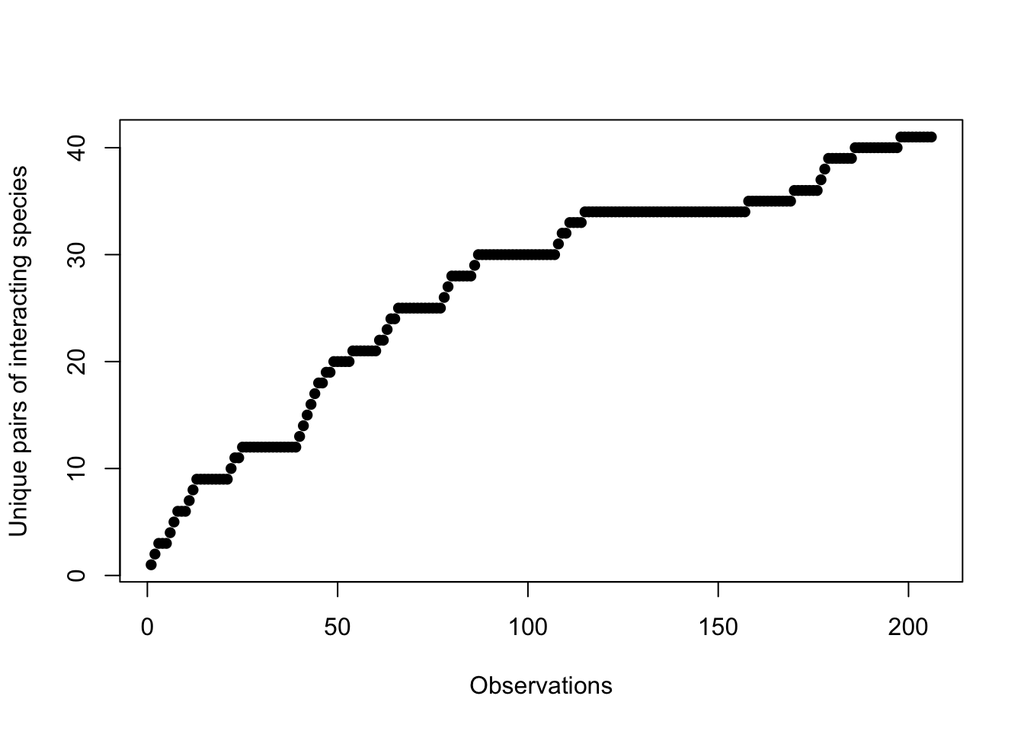

```r
curve_analysis <- drop_ufos(scored)
curve_analysis <- curve_analysis[complete.cases(curve_analysis),]
curve_analysis <- curve_analysis[,c(4,5,6,10,13)]
# Convert the dates and times into a readable format and sort the dataset by them:
library(chron)
curve_analysis$Date.of.recording <- as.Date(curve_analysis$Date.of.recording, format = "%d %B %y")
# This will makes the times readable by 'chron':
curve_analysis$Time.of.Recording <- paste(curve_analysis$Time.of.Recording, ":00", sep = "")
curve_analysis$Time.of.Recording <- chron(times = curve_analysis$Time.of.Recording)
# Sort by date and time:
curve_analysis <- curve_analysis[order(curve_analysis$Date.of.recording, curve_analysis$Time.of.Recording, decreasing = TRUE),]

species_pairs <- list()
rarefaction <- data.frame(matrix(NA, nrow = nrow(curve_analysis), ncol = 2))
colnames(rarefaction) <- c("Observation", "Unique Pairs")
for(i in 1:nrow(curve_analysis)) {
  new_pair <- c(as.character(curve_analysis$Species.A[i]), as.character(curve_analysis$Species.B[i]))
  species_pairs <- c(species_pairs, list(new_pair))
  rarefaction[i,1] <- i
  rarefaction[i,2] <- length(unique(species_pairs))
}
plot(rarefaction$Observation, rarefaction$`Unique Pairs`, pch = 16, xlab = "Observations", ylab = "Unique pairs of interacting species")
```

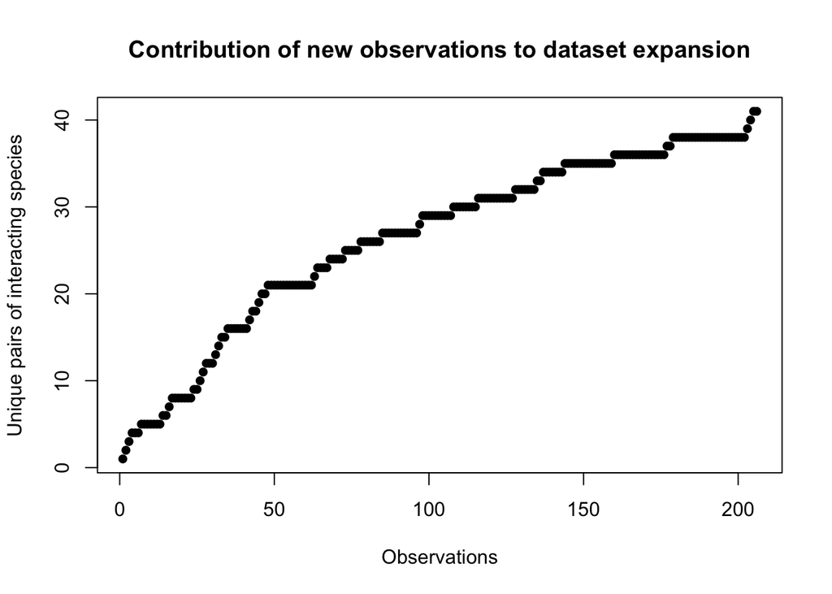

```r
# Now order the observations according to scoring time rather than recording time:
curve_analysis2 <- drop_ufos(scored)
curve_analysis2 <- curve_analysis2[complete.cases(curve_analysis2),]
curve_analysis2 <- curve_analysis2[,c(3,10,13)]
curve_analysis2$Date.of.scoring <- as.Date(curve_analysis2$Date.of.scoring, format = "%d %B %Y")
curve_analysis2 <- curve_analysis2[order(curve_analysis2$Date.of.scoring, decreasing = TRUE),]

species_pairs2 <- list()
rarefaction2 <- data.frame(matrix(NA, nrow = nrow(curve_analysis), ncol = 2))
colnames(rarefaction2) <- c("Observation", "Unique Pairs")
for(i in 1:nrow(curve_analysis2)) {
  new_pair <- c(as.character(curve_analysis2$Species.A[i]), as.character(curve_analysis2$Species.B[i]))
  species_pairs2 <- c(species_pairs2, list(new_pair))
  rarefaction2[i,1] <- i
  rarefaction2[i,2] <- length(unique(species_pairs2))
}
plot(rarefaction2$Observation, rarefaction2$`Unique Pairs`, pch = 16, xlab = "Observations", ylab = "Unique pairs of interacting species", main = "Contribution of new observations to dataset expansion")
```

This is the code used to generate Supplementary Figure 1:

```r
# png("/Users/David/Documents/College/2017–18/Winter 2018/FBQ_git/Figure_S1.png", width = 2880, height = 1800, pointsize = 64)
# setEPS()
# postscript("/Users/David/Documents/College/2017–18/Winter 2018/FBQ_git/Figure_S1.eps")
# plot(rarefaction2$Observation, rarefaction2$`Unique Pairs`, pch = 16, xlab = "Observations", ylab = "Unique pairs of interacting species", main = "Contribution of new observations to dataset expansion")
# dev.off()
```

### Breakdown by diet

```r
diet <- read.csv("/Users/David/Documents/College/2017–18/Winter 2018/FBQ_git/diet.csv", sep = ",", strip.white = TRUE)

# Add dietary information for both Species A and Species B
for(i in 1:nrow(both_group)) {
  both_group[i, 12] <- diet$Diet[diet$Species == as.character(both_group$Species.A[i])]
  both_group[i, 13] <- diet$Diet[diet$Species == as.character(both_group$Species.B[i])]
}
colnames(both_group)[12:13] <- c("Diet.A", "Diet.B")

# Now subsample the test frame to include only those interactions that take place between
# species with the same diet:
test_benth <- both_group[both_group$Diet.A == "Benthic Invertebrate Consumer" &
                         both_group$Diet.B == "Benthic Invertebrate Consumer",]
nrow(test_benth)
```

```
## [1] 0
```

```r
test_omni <- both_group[both_group$Diet.A == "Omnivore" & both_group$Diet.B == "Omnivore",]
nrow(test_omni)
```

```
## [1] 16
```

```r
test_herb <- both_group[both_group$Diet.A == "Herbivore/Detritivore" & both_group$Diet.B == "Herbivore/Detritivore",]
nrow(test_herb)
```

```
## [1] 4
```

```r
test_coral <- both_group[both_group$Diet.A == "Corallivore" & both_group$Diet.B == "Corallivore",]
nrow(test_coral)
```

```
## [1] 0
```

```r
# Test the validity of Lanchester's laws for interaction subsets of non-zero length.
# Omnivores:
sum(test_omni$Linear.True)/nrow(test_omni)
```

```
## [1] 0.8125
```

```r
sum(test_omni$Square.True)/nrow(test_omni)
```

```
## [1] 0.5625
```

```r
dbinom(sum(test_omni$Linear.True), size = nrow(test_omni), prob = 1/2)
```

```
## [1] 0.008544922
```

```r
dbinom(sum(test_omni$Square.True), size = nrow(test_omni), prob = 1/2)
```

```
## [1] 0.1745605
```

```r
dif3 <- test_omni[test_omni$Linear.Law.Prediction != test_omni$Square.Law.Prediction,]
nrow(dif3)
```

```
## [1] 4
```

```r
sum(dif3$Linear.True)/nrow(dif3)
```

```
## [1] 1
```

```r
dbinom(sum(dif3$Linear.True), size = nrow(dif3), prob = 1/2)
```

```
## [1] 0.0625
```

```r
# Herbivores/Detritivores:
sum(test_herb$Linear.True)/nrow(test_herb)
```

```
## [1] 1
```

```r
sum(test_herb$Square.True)/nrow(test_herb)
```

```
## [1] 0.25
```

```r
dbinom(sum(test_herb$Linear.True), size = nrow(test_herb), prob = 1/2)
```

```
## [1] 0.0625
```

```r
dbinom(sum(test_herb$Square.True), size = nrow(test_herb), prob = 1/2)
```

```
## [1] 0.25
```

```r
dif4 <- test_herb[test_herb$Linear.Law.Prediction != test_herb$Square.Law.Prediction,]
nrow(dif4)
```

```
## [1] 3
```

```r
sum(dif4$Linear.True)/nrow(dif4)
```

```
## [1] 1
```

```r
dbinom(sum(dif4$Linear.True), size = nrow(dif4), prob = 1/2)
```

```
## [1] 0.125
```

```r
# Re-run everything with mass raised to two thirds:
for(i in 1:nrow(both_group2)) {
  both_group2[i, 12] <- diet$Diet[diet$Species == as.character(both_group2$Species.A[i])]
  both_group2[i, 13] <- diet$Diet[diet$Species == as.character(both_group2$Species.B[i])]
}
colnames(both_group2)[12:13] <- c("Diet.A", "Diet.B")
test_benth2 <- both_group2[both_group2$Diet.A == "Benthic Invertebrate Consumer" &
                         both_group2$Diet.B == "Benthic Invertebrate Consumer",]
test_omni2 <- both_group2[both_group2$Diet.A == "Omnivore" & both_group2$Diet.B == "Omnivore",]
test_herb2 <- both_group2[both_group2$Diet.A == "Herbivore/Detritivore" & both_group2$Diet.B == "Herbivore/Detritivore",]
test_coral2 <- both_group2[both_group2$Diet.A == "Corallivore" & both_group2$Diet.B == "Corallivore",]

sum(test_omni2$Linear.True)/nrow(test_omni2)
```

```
## [1] 0.5625
```

```r
sum(test_omni2$Square.True)/nrow(test_omni2)
```

```
## [1] 0.25
```

```r
dbinom(sum(test_omni2$Linear.True), size = nrow(test_omni2), prob = 1/2)
```

```
## [1] 0.1745605
```

```r
dbinom(sum(test_omni2$Square.True), size = nrow(test_omni2), prob = 1/2)
```

```
## [1] 0.027771
```

```r
dif5 <- test_omni2[test_omni2$Linear.Law.Prediction != test_omni2$Square.Law.Prediction,]
nrow(dif5)
```

```
## [1] 5
```

```r
sum(dif5$Linear.True)/nrow(dif5)
```

```
## [1] 1
```

```r
dbinom(sum(dif5$Linear.True), size = nrow(dif5), prob = 1/2)
```

```
## [1] 0.03125
```

```r
sum(test_herb2$Linear.True)/nrow(test_herb2)
```

```
## [1] 0.75
```

```r
sum(test_herb2$Square.True)/nrow(test_herb2)
```

```
## [1] 0
```

```r
dbinom(sum(test_herb2$Linear.True), size = nrow(test_herb2), prob = 1/2)
```

```
## [1] 0.25
```

```r
dbinom(sum(test_herb2$Square.True), size = nrow(test_herb2), prob = 1/2)
```

```
## [1] 0.0625
```

```r
dif6 <- test_herb2[test_herb2$Linear.Law.Prediction != test_herb2$Square.Law.Prediction,]
nrow(dif6)
```

```
## [1] 3
```

```r
sum(dif6$Linear.True)/nrow(dif6)
```

```
## [1] 1
```

```r
dbinom(sum(dif6$Linear.True), size = nrow(dif6), prob = 1/2)
```

```
## [1] 0.125
```

# Analyses not included in the manuscript

These include exploratory analyses as well as applications of previously proposed methods to the fish dataset (e.g., Shelley et al.’s (2004) logistic regression).

### Most often interacting species

Subsample the data sheets down to the 10 most often interacting species. This will increase completeness (substantially) and linearity (slightly), but give you fewer data points to work with.

```r
mostoften <- function(sheet, df, n) {
  occurrences <- tail(sort(table(unlist(sheet[,c("Species.A", "Species.B")]))), n)
  max_n <- as.character(as.data.frame(occurrences)[,1])
  max_n_matrix <- subset(df, select = max_n)
  max_n_matrix <- subset(max_n_matrix, rownames(max_n_matrix) %in% max_n)
  max_n_matrix <- max_n_matrix[order(row.names(max_n_matrix)), order(colnames(max_n_matrix))]
  return(max_n_matrix)
}

dommatrix_max10 <- mostoften(sheet4, dommatrix, 10)
scoredmatrix_max10 <- mostoften(scored4, scoredmatrix, 10)
bothmatrix_max10 <- mostoften(both4, bothmatrix, 10)
domooo_max10 <- mostoften(sheet_ooo4, domooo, 10)
scoredooo_max10 <- mostoften(scored_ooo4, scoredooo, 10)
bothooo_max10 <- mostoften(both_ooo4, bothooo, 10)

dommax10 <- convert_to_df(dommatrix_max10)
scoredmax10 <- convert_to_df(scoredmatrix_max10)
bothmax10 <- convert_to_df(bothmatrix_max10)
liveooomax10 <- convert_to_df(domooo_max10)
scoredooomax10 <- convert_to_df(scoredooo_max10)
bothooomax10 <- convert_to_df(bothooo_max10)

paste("The completeness of the live-only 10-species matrix is ", compl(dommax10), "%", sep = "")
paste("The completeness of the video-only 10-species matrix is ", compl(scoredmax10), "%", sep = "")
paste("The completeness of the combined 10-species matrix is ", compl(bothmax10), "%", sep = "")
paste("The completeness of the live-only one-on-one 10-species matrix is ", compl(liveooomax10), "%", sep = "")
paste("The completeness of the video-only one-on-one 10-species matrix is ", compl(scoredooomax10), "%", sep = "")
paste("The completeness of the combined one-on-one 10-species matrix is ", compl(bothooomax10), "%", sep = "")

cbi_max10 <- cbi_hierarchy(dommax10)
cbi_scoredmax10 <- cbi_hierarchy(scoredmax10)
cbi_bothmax10 <- cbi_hierarchy(bothmax10)
cbi_liveooomax10 <- cbi_hierarchy(liveooomax10)
cbi_scoredooomax10 <- cbi_hierarchy(scoredooomax10)
cbi_bothooomax10 <- cbi_hierarchy(bothooomax10)

devries(dommax10, Nperms = 10000, history = FALSE, plot = TRUE)
devries(scoredmax10, Nperms = 10000, history = FALSE, plot = TRUE)
devries(bothmax10, Nperms = 10000, history = FALSE, plot = TRUE)
devries(liveooomax10, Nperms = 10000, history = FALSE, plot = TRUE)
devries(scoredooomax10, Nperms = 10000, history = FALSE, plot = TRUE)
devries(bothooomax10, Nperms = 10000, history = FALSE, plot = TRUE)
```

### I&SI rank

A third measure of dominance that is particularly applicable to weakly but significantly linear dominance hierarchies, implemented as described in Schmid & de Vries (2013).

```r
library(compete)
i_and_si_liveooo <- isi13(liveoooall, nTries = 10)
rev(i_and_si_liveooo$best_order) # The order is given from least to most dominant by default

i_and_si_videoooo <- isi13(scoredoooall, nTries = 10)
rev(i_and_si_videoooo$best_order)

i_and_si_bothooo <- isi13(bothoooall, nTries = 10)
rev(i_and_si_bothooo$best_order)

i_and_si <- isi13(dommax10, nTries = 10)
rev(i_and_si$best_order)

i_and_si_scored <- isi13(scoredmax10, nTries = 10)
rev(i_and_si_scored$best_order)

i_and_si_both <- isi13(bothmax10, nTries = 10)
rev(i_and_si_both$best_order)

# Create a data frame with alphabetically ordered species and their corresponding I&SI ranks:
isi_both <- i_and_si_bothooo$best_order
isi_both <- setdiff(isi_both, "Cornetfish")
test_isi <- data.frame(matrix(NA, nrow = length(isi_both), ncol = 2))
colnames(test_isi) <- c("Species", "I_SI_Rank")
test_isi$Species <- sort(isi_both)
test_isi$I_SI_Rank <- match(sort(isi_both), isi_both)
```

### Nonlinear models

Do simple nonlinear models (exponential, logarithmic, quadratic) explain the relationship between individual fighting ability (as determined by CBI and the frequency of winning) and body mass?

```r
# Add mass squared to the test frame:
both_test[,9] <- both_test$Mass^2
colnames(both_test)[9] <- "Mass_Squared"

stats <- function(df) {
  results <- data.frame(matrix(NA, nrow = 2, ncol = 14))
  # Columns represent different statistics associated with each model. Spearman's rho
  # and Pearson's coefficient are included for comparison; if the former is significant
  # but the latter is not, this shows that the relationship is monotonic but nonlinear.
  colnames(results) <- c("rho", "Spear_p-value", "cor", "Pear_p-value", "linAIC", "expRsq", "exp_p-value", "expAIC", "logRsq", "log_p-value", "logAIC", "quadrRsq", "quadr_p-value", "quadrAIC")
  # Rows represent dependent variables:
  row.names(results) <- c("CBI_Mass", "WinFreq_Mass")
  spear_mass_CBI <- cor.test(df$CBI, df$Mass, method = "spearman", alternative = "two.sided")
  spear_mass_WinFreq <- cor.test(df$WinFreq, df$Mass, method = "spearman", alternative = "two.sided")
  pear_mass_CBI <- cor.test(df$CBI, df$Mass, method = "pearson", alternative = "two.sided")
  pear_mass_WinFreq <- cor.test(df$WinFreq, df$Mass, method = "pearson", alternative = "two.sided")
  linear_mass_CBI <- lm(df$CBI ~ df$Mass)
  expo_mass_CBI <- lm(log(df$CBI) ~ df$Mass)
  loga_mass_CBI <- lm(df$CBI ~ log(df$Mass))
  quadra_mass_CBI <- lm(df$CBI ~ df$Mass + df$Mass_Squared)
  linear_mass_WinFreq <- lm(df$WinFreq  ~ df$Mass)
  # No exponential model for winning frequency: the minimum winning frequency observed
  # in the dataset is 0, and simple log transformation therefore cannot be applied to it.
  loga_mass_WinFreq <- lm(df$WinFreq  ~ log(df$Mass))
  quadra_mass_WinFreq <- lm(df$WinFreq  ~ df$Mass + df$Mass_Squared)
  results[1,1] <- spear_mass_CBI$estimate; results[1,2] <- spear_mass_CBI$p.value
  results[1,3] <- pear_mass_CBI$estimate; results[1,4] <- pear_mass_CBI$p.value
  results[1,5] <- AIC(linear_mass_CBI); results[1,6] <- summary(expo_mass_CBI)$r.squared
  results[1,7] <- summary(expo_mass_CBI)$coefficients[,4][[2]]
  results[1,8] <- AIC(expo_mass_CBI); results[1,9] <- summary(loga_mass_CBI)$r.squared
  results[1,10] <- summary(loga_mass_CBI)$coefficients[,4][[2]]
  results[1,11] <- AIC(loga_mass_CBI); results[1,12] <- summary(quadra_mass_CBI)$r.squared
  results[1,13] <- summary(quadra_mass_CBI)$coefficients[,4][[2]]
  results[1,14] <- AIC(quadra_mass_CBI)
  results[2,1] <- spear_mass_WinFreq$estimate; results[2,2] <- spear_mass_WinFreq$p.value
  results[2,3] <- pear_mass_WinFreq$estimate; results[2,4] <- pear_mass_WinFreq$p.value
  results[2,5] <- AIC(linear_mass_WinFreq)
  results[2,9] <- summary(loga_mass_WinFreq)$r.squared
  results[2,10] <- summary(loga_mass_WinFreq)$coefficients[,4][[2]]
  results[2,11] <- AIC(loga_mass_WinFreq)
  results[2,12] <- summary(quadra_mass_WinFreq)$r.squared
  results[2,13] <- summary(quadra_mass_WinFreq)$coefficients[,4][[2]]
  results[2,14] <- AIC(quadra_mass_WinFreq)
  return(results)
}

both_test_results <- stats(both_test)

# Adjust the p-values for multiple comparisons:
library(stats)
pvalues <- unlist(both_test_results[,c(2,4,7,10,13)])
p.adjust(pvalues, "bonferroni", sum(!is.na(pvalues)))
```

### Logistic regression

The code below is an implementation of the logistic regression analysis described by Shelley et al. (2004). Given the paucity of data, no pairwise comparisons were made; each of the selected species was compared against all other species it interacted with. Unlike Shelley et al. (2004), we regress against both group size and group size squared.

```r
# Extract those species that participated in an interaction with more than one individual
# at least a given number of times:
atleastoncemorethan <- function(df, n) {
  output <- vector()
  species <- union(unique(df$Species.A), unique(df$Species.B))
  for (i in species) {
    a.frame <- df[df$Species.A == i,]
    b.frame <- df[df$Species.B == i,]
    if (sum(!is.na(a.frame$Group.A) & a.frame$Group.A > 1) + sum(!is.na(b.frame$Group.B) & b.frame$Group.B > 1) >= n) {
      output <- c(output, as.character(i))
    }
  }
  return(unique(output))
}

# Some ad hoc data clean-up before applying the atleastoncemorethan() function:
scored4$Group.B <- as.numeric(as.character(scored4$Group.B))
both4$Group.B <- as.numeric(both4$Group.B)

# Include only those species that had a group size greater than 1 at least twice. This
# ensures that there is variability in the predictor variable.
live_logres <- sheet4[sheet4$Species.A %in% atleastoncemorethan(sheet4, 2) &
                      sheet4$Species.B %in% atleastoncemorethan(sheet4, 2),]
video_logres <- scored4[scored4$Species.A %in% atleastoncemorethan(scored4, 2) &
                        scored4$Species.B %in% atleastoncemorethan(scored4, 2),]
both_logres <- both4[both4$Species.A %in% atleastoncemorethan(both4, 2) &
                    both4$Species.B %in% atleastoncemorethan(both4, 2),]

# Convert from wide to long format: every two successive rows correspond to one
# interaction, with the winner coded as "1" and the loser coded as "0".
wide_to_long <- function(df) {
  longframe <- data.frame(matrix(NA, ncol = 3, nrow = 2*nrow(df)))
  colnames(longframe) <- c("Species", "Group_Size", "Is_Winner")
  for (i in 1:nrow(df)) {
    longframe$Species[2*i-1] <- as.character(df$Species.A[i])
    longframe$Species[2*i] <- as.character(df$Species.B[i])
    longframe$Group_Size[2*i-1] <- df$Group.A[i]
    longframe$Group_Size[2*i] <- df$Group.B[i]
    if (identical(as.character(df$Species.A[i]), as.character(df$Winner[i])) == TRUE) {
      longframe$Is_Winner[2*i-1] <- 1
      longframe$Is_Winner[2*i] <- 0
    }
    if (identical(as.character(df$Species.B[i]), as.character(df$Winner[i])) == TRUE) {
      longframe$Is_Winner[2*i-1] <- 0
      longframe$Is_Winner[2*i] <- 1
    }
  }
  return(longframe)
}

# Make sure winner is always either A or B, and that you have group sizes for all rows:
live_long <- wide_to_long(live_logres)
nrow(live_long) == nrow(live_long[!is.na(live_long$Is_Winner),])
nrow(live_long) == nrow(live_long[!is.na(live_long$Group_Size),])
video_long <- wide_to_long(video_logres)
nrow(video_long) == nrow(video_long[!is.na(video_long$Is_Winner),])
nrow(video_long) == nrow(video_long[!is.na(video_long$Group_Size),])
both_long <- wide_to_long(both_logres)
nrow(both_long) == nrow(both_long[!is.na(both_long$Is_Winner),])
nrow(both_long) == nrow(both_long[!is.na(both_long$Group_Size),])

# Add group size squared
square_it <- function(df) {
  a <- ncol(df)
  df[,a+1] <- df$Group_Size^2
  colnames(df)[a+1] <- "Group_Size_Squared"
  return(df)
}

live_long <- square_it(live_long)
video_long <- square_it(video_long)
both_long <- square_it(both_long)

# Extract those species that won and lost at least 1 interaction. This ensures that there
# is variability in the dependent variable:
won_once <- function(df) {
  output <- vector()
  species <- unique(df$Species)
  for(i in species) {
    subset.frame <- df[df$Species == i,]
    if(0 %in% subset.frame$Is_Winner & 1 %in% subset.frame$Is_Winner) {
      output <- c(output, i)
    }
  }
  return(df[df$Species %in% output,])
}

# This function creates a data frame with logistic regression results. The regression is
# run against group size if x is FALSE and against group size squared if x is TRUE.
library(pscl)
species_logistic <- function(df, x = TRUE) {
  j <- 1
  species <- unique(df$Species)
  results <- data.frame(matrix(NA, nrow = length(species), ncol = 6))
  colnames(results) <- c("Species", "Coefficient", "p-value", "McFaddenpseudoRsq", "AIC", "n")
  for(i in species) {
    if (x == FALSE) {
      model <- glm(df$Is_Winner[df$Species == i] ~ df$Group_Size[df$Species == i])
    } else {
      model <- glm(df$Is_Winner[df$Species == i] ~ df$Group_Size_Squared[df$Species == i] + df$Group_Size[df$Species == i])
    }
    results[j,1] <- i
    results[j,2] <- model$coefficients[2]
    results[j,3] <- coef(summary(model))[,4][2]
    results[j,4] <- pR2(model)[4]
    results[j,5] <- AIC(model)
    results[j,6] <- nrow(df[df$Species == i,])
    j <- j + 1
  }
  return(results)
}

# Linear group size
species_logistic(won_once(live_long), FALSE)
species_logistic(won_once(video_long), FALSE)
species_logistic(won_once(both_long), FALSE)

# Group size squared
species_logistic(won_once(live_long), TRUE)
species_logistic(won_once(video_long), TRUE)
species_logistic(won_once(both_long), TRUE)
```

### Chi-squared

This is an alternative way of testing Lanchester’s laws. Instead of applying the binomial test to a binary variable (prediction: correct, incorrect), we apply $\chi^2$ to a 4-entry contingency table (correctly predicted win, incorrectly predicted win, correctly predicted loss, incorrectly predicted loss):

```r
populate_cont_table <- function(df, law) {
  # Create a contingency table whose rows represent (1) Wins, (2) Losses predicted
  # by the linear law and whose columns represent observed (1) Wins and (2) Losses
  cont_table <- matrix(0, nrow = 2, ncol = 2)
  # Focus solely on Species A. This is arbitrary; we could instead focus on B by
  # interchanging individual rows and individual columns.
  for(i in 1:nrow(df)) {
    # A won:
    if (identical(as.character(df$Species.A[i]), as.character(df$Winner[i])) == TRUE) {
      # A was predicted to win:
      if (identical(as.character(df$Species.A[i]), as.character(df[i, paste(law, ".Law.Prediction", sep = "")])) == TRUE) {
        inc(cont_table[1,1])
        # A was predicted to lose:
      } else {
        inc(cont_table[2,1])
      }
      # A lost:
    } else {
      # A was predicted to win:
      if (identical(as.character(df$Species.A[i]), as.character(df[i, paste(law, ".Law.Prediction", sep = "")])) == TRUE) {
        inc(cont_table[1,2])
        # A was predicted to lose:
      } else {
        inc(cont_table[2,2])
      }
    }
  }
  return(cont_table)
}

chisq.test(populate_cont_table(both_group, "Linear"))
chisq.test(populate_cont_table(both_group, "Square"))
chisq.test(populate_cont_table(both_group2, "Linear"))
chisq.test(populate_cont_table(both_group2, "Square"))

# To distinguish between the linear and square laws, we run another chi-squared test.
# This time, the contingency table has the following structure: [1,1] correctly
# predicted by both models, [1,2] correctly predicted by the linear law but not the
# square law, [2,1] correctly predicted by the square law but not the linear law,
# [2,2] predicted incorrectly by both laws.
law_vs_law <- function(df) {
  cont_table <- matrix(0, nrow = 2, ncol = 2)
  for(i in 1:nrow(df)) {
    if (df$Linear.True[i] == 1 & df$Square.True[i] == 1) {
      inc(cont_table[1,1])
    } else if (df$Linear.True[i] == 1 & df$Square.True[i] == 0) {
      inc(cont_table[1,2])
    } else if (df$Linear.True[i] == 0 & df$Square.True[i] == 1) {
      inc(cont_table[2,1])
    } else {
      inc(cont_table[2,2])
    }
  }
  return(cont_table)
}

laws_mass <- law_vs_law(both_group)
laws_mass2_3 <- law_vs_law(both_group2)
chisq.test(laws_mass)
chisq.test(laws_mass2_3)
```

# References

- Clutton-Brock TH, Albon SD, Gibson RM, Guinness FE 1979 The logical stag: adaptive aspects of fighting in red deer (*Cervus elaphus* L.). Anim Behav 27: 211–225
- Clutton-Brock TH, Guinness FE, Albon SD 1982 *Red Deer: Behaviour and Ecology of Two Sexes*. Chicago, IL: Univ of Chicago Press
- Randall JE 2005 *Reef and Shore Fishes of the South Pacific: New Caledonia to Tahiti and the Pitcairn Islands*. Honolulu, HI: Univ of Hawaii Press
- Schmid VS, de Vries H. 2013. Finding a dominance order most consistent with a linear hierarchy: an improved algorithm for the I&SI method. Anim Behav 86: 1097–1105
- Shelley EL, Tanaka MYU, Ratnathicam AR, Blumstein DT. 2004. Can Lanchester’s laws help explain interspecific dominance in birds? Condor 106: 395–400